# Bike Share Case Study

##Installing packages

```r
install.packages("tidyverse")
install.packages("lubridate")
install.packages("ggplot2")
```

```r
library("tidyverse")
library("lubridate")
library("ggplot2")
```

##Importing data

```r
March_21 <- read_csv("202103-divvy-tripdata.csv")
April_21 <- read_csv("202104-divvy-tripdata.csv")
May_21 <- read_csv("202105-divvy-tripdata.csv")
June_21 <- read_csv("202106-divvy-tripdata.csv")
July_21 <- read_csv("202107-divvy-tripdata.csv")
August_21 <- read_csv("202108-divvy-tripdata.csv")
September_21 <- read_csv("202109-divvy-tripdata.csv")
October_21 <- read_csv("202110-divvy-tripdata.csv")
November_21 <- read_csv("202111-divvy-tripdata.csv")
December_21 <- read_csv("202112-divvy-tripdata.csv")
January_22 <- read_csv("202201-divvy-tripdata.csv")
February_22 <- read_csv("202202-divvy-tripdata.csv")
```

##Checking the column names of each csv file

```r
colnames(March_21)
```

```
 [1] "ride_id"            "rideable_type"      "started_at"
 [4] "ended_at"           "start_station_name" "start_station_id"
 [7] "end_station_name"   "end_station_id"     "start_lat"
[10] "start_lng"          "end_lat"            "end_lng"
[13] "member_casual"
```

```r
colnames(April_21)
```

```
 [1] "ride_id"            "rideable_type"      "started_at"
 [4] "ended_at"           "start_station_name" "start_station_id"
 [7] "end_station_name"   "end_station_id"     "start_lat"
[10] "start_lng"          "end_lat"            "end_lng"
[13] "member_casual"
```

```r
colnames(May_21)
```

```
 [1] "ride_id"            "rideable_type"      "started_at"
 [4] "ended_at"           "start_station_name" "start_station_id"
 [7] "end_station_name"   "end_station_id"     "start_lat"
[10] "start_lng"          "end_lat"            "end_lng"
[13] "member_casual"
```

```r
colnames(June_21)
```

```
 [1] "ride_id"            "rideable_type"      "started_at"
 [4] "ended_at"           "start_station_name" "start_station_id"
 [7] "end_station_name"   "end_station_id"     "start_lat"
[10] "start_lng"          "end_lat"            "end_lng"
[13] "member_casual"
```

```r
colnames(July_21)
```

```
 [1] "ride_id"            "rideable_type"      "started_at"
 [4] "ended_at"           "start_station_name" "start_station_id"
 [7] "end_station_name"   "end_station_id"     "start_lat"
[10] "start_lng"          "end_lat"            "end_lng"
[13] "member_casual"
```

```r
colnames(August_21)
```

```
 [1] "ride_id"            "rideable_type"      "started_at"
 [4] "ended_at"           "start_station_name" "start_station_id"
 [7] "end_station_name"   "end_station_id"     "start_lat"
[10] "start_lng"          "end_lat"            "end_lng"
[13] "member_casual"
```

```r
colnames(December_21)
```

```
 [1] "ride_id"            "rideable_type"      "started_at"
 [4] "ended_at"           "start_station_name" "start_station_id"
 [7] "end_station_name"   "end_station_id"     "start_lat"
[10] "start_lng"          "end_lat"            "end_lng"
[13] "member_casual"
```

```r
colnames(February_22)
```

```
 [1] "ride_id"            "rideable_type"      "started_at"
 [4] "ended_at"           "start_station_name" "start_station_id"
 [7] "end_station_name"   "end_station_id"     "start_lat"
[10] "start_lng"          "end_lat"            "end_lng"
[13] "member_casual"
```

#DATA CLEANING AND MANIPULATION

##I changed some column headings for consistency in all 12 csv files

```r
March_21 <-rename(March_21, bike_type = rideable_type, member_type = member_casual, start_time = started_at, end_time = ended_at)
April_21 <-rename(April_21, bike_type = rideable_type, member_type = member_casual, start_time = started_at, end_time = ended_at)
May_21 <-rename(May_21, bike_type = rideable_type, member_type = member_casual, start_time = started_at, end_time = ended_at)
June_21 <-rename(June_21, bike_type = rideable_type, member_type = member_casual, start_time = started_at, end_time = ended_at)
July_21 <-rename(July_21, bike_type = rideable_type, member_type = member_casual, start_time = started_at, end_time = ended_at)
August_21 <-rename(August_21, bike_type = rideable_type, member_type = member_casual, start_time = started_at, end_time = ended_at)
September_21 <-rename(September_21, bike_type = rideable_type, member_type = member_casual, start_time = started_at, end_time = ended_at)
October_21 <-rename(October_21, bike_type = rideable_type, member_type = member_casual, start_time = started_at, end_time = ended_at)
November_21 <-rename(November_21, bike_type = rideable_type, member_type = member_casual, start_time = started_at, end_time = ended_at)
December_21 <-rename(December_21, bike_type = rideable_type, member_type = member_casual, start_time = started_at, end_time = ended_at)
January_22 <-rename(January_22, bike_type = rideable_type, member_type = member_casual, start_time = started_at, end_time = ended_at)
February_22 <-rename(February_22, bike_type = rideable_type, member_type = member_casual, start_time = started_at, end_time = ended_at)
```

##I merged all 12 months of data together

```r
all_trips <- (bind_rows(March_21, April_21, May_21, June_21, July_21, August_21, September_21, October_21, November_21, December_21, January_22, February_22))
```

##I extracted the date, month, day, and year of each ride from start_time

```r
all_trips$date <- as.Date(all_trips$start_time)
all_trips$year <- format(as.Date(all_trips$date), "%Y")
all_trips <- all_trips %>%
  mutate(weekday = wday(start_time, label=TRUE, abbr=TRUE))
all_trips <- all_trips %>%
  mutate(month = month(start_time, label=TRUE, abbr=TRUE))
```

##I viewed the new data frame Notes:I viewed the new data data frame to enusre the new additions to the data were in the correct format

```r
View(all_trips)
```

##I calculated the ride_length

```r
all_trips$ride_length <- difftime(all_trips$end_time,all_trips$start_time, units = "mins")
```

##Removing rows with negative ride_length and startstation name HQ QR

```r
all_trips_v2 <- all_trips[!(all_trips$start_station_name == "HQ QR" | all_trips$ride_length<0),]
```

##Removing rows with na values

```r
all_trips_v2 = na.omit(all_trips_v2)
```

##I changed the data type of ride_length to numeric

```r
all_trips_v2$ride_length <- as.numeric(as.duration(all_trips_v2$ride_length))
```

##checking the new dataframe

```r
summary(all_trips_v2$ride_length)
```

```
   Min. 1st Qu.  Median    Mean 3rd Qu.    Max.
      0     412     725    1298    1315 3356649
```

```r
glimpse(all_trips_v2)
```

```
Rows: 4,630,987
Columns: 18
$ ride_id            <chr> "CFA86D4455AA1030", "30D9DC61227D1AF3"~
$ bike_type          <chr> "classic_bike", "classic_bike", "class~
$ start_time         <dttm> 2021-03-16 08:32:30, 2021-03-28 01:26~
$ end_time           <dttm> 2021-03-16 08:36:34, 2021-03-28 01:36~
$ start_station_name <chr> "Humboldt Blvd & Armitage Ave", "Humbo~
$ start_station_id   <chr> "15651", "15651", "15443", "TA13080000~
$ end_station_name   <chr> "Stave St & Armitage Ave", "Central Pa~
$ end_station_id     <chr> "13266", "18017", "TA1308000043", "133~
$ start_lat          <dbl> 41.91751, 41.91751, 41.84273, 41.96881~
$ start_lng          <dbl> -87.70181, -87.70181, -87.63549, -87.6~
$ end_lat            <dbl> 41.91774, 41.91417, 41.83066, 41.95283~
$ end_lng            <dbl> -87.69139, -87.71676, -87.64717, -87.6~
$ member_type        <chr> "casual", "casual", "casual", "casual"~
$ date               <date> 2021-03-16, 2021-03-28, 2021-03-11, 2~
$ year               <chr> "2021", "2021", "2021", "2021", "2021"~
$ weekday            <ord> Tue, Sun, Thu, Thu, Sun, Sat, Sat, Tue~
$ month              <ord> Mar, Mar, Mar, Mar, Mar, Mar, Mar, Mar~
$ ride_length        <dbl> 244, 627, 984, 1739, 1076, 1252, 692, ~
```

```r
is.numeric(all_trips_v2$ride_length)
```

```
[1] TRUE
```

#DATA ANALYSIS

##grouped mean,max,min,median by customer_type and weekday

```r
all_trips_summary <-
  all_trips_v2 %>%
  group_by(member_type, weekday) %>%
  summarise(number_of_rides=n(),
            average_ride_length=mean(ride_length),
            min_ride_legnth=min(ride_length),
            median_ride_legnth=median(ride_length),
            max_ride_legnth=max(ride_length))
```

##Checking all_trips_summary

```r
View (all_trips_summary)
```

##VISUALIZATIONS

##Visualized count of each member_type

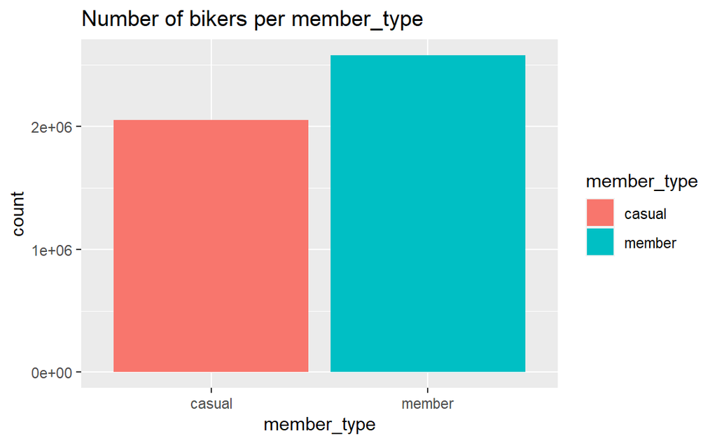

```r
ggplot(data=all_trips_v2)+
  geom_bar(mapping=aes(x = member_type, fill = member_type)) +
  labs(title = "Number of bikers per member_type")
```

##Visualized count of each biker per bike_type##

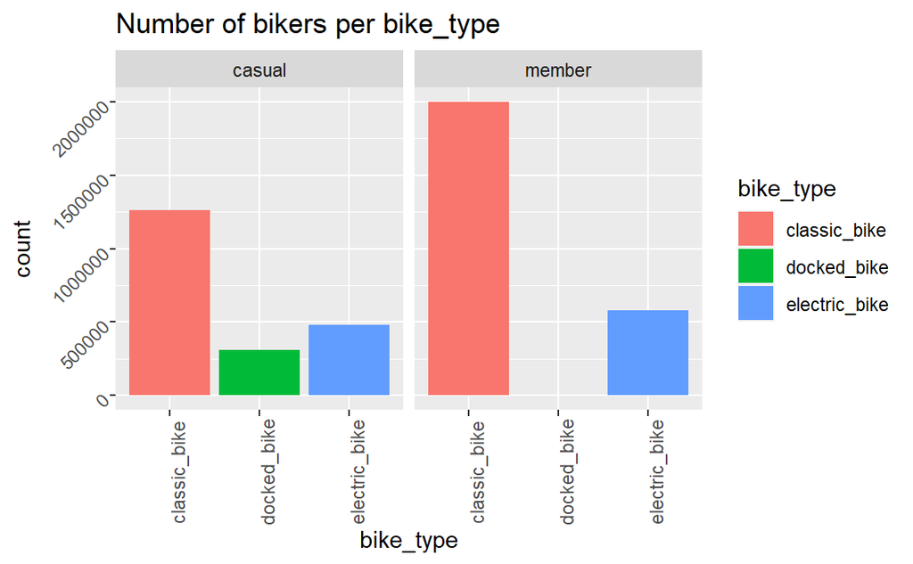

```r
ggplot(data=all_trips_v2)+
  geom_bar(mapping=aes(x = bike_type, fill = bike_type)) +
  facet_wrap(~member_type)+
   theme(axis.text.x = element_text(angle = 90), axis.text.y = element_text(angle = 45))+
labs(title ="Number of bikers per bike_type")
```

##Visualized the number of rides vs member_type##

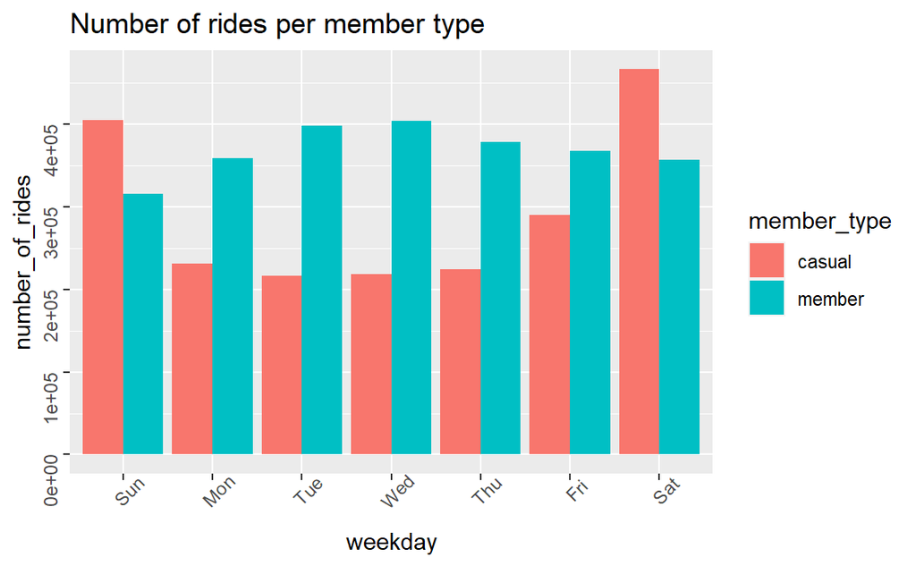

```r
ggplot(data = all_trips_summary)+
       (mapping=aes(x = weekday, y = number_of_rides, fill = member_type))+
      (geom_col(position = "dodge"))+
      theme(axis.text.x = element_text(angle = 90), axis.text.y = element_text(angle = 90))+
      labs(title = "Number of rides per member type")+
    theme(axis.text.x = element_text(angle = 45 ), axis.text.y = element_text(angle = 90))
```

##Visualized the average ride duration per memebr type

[figure not shown]

```r
ggplot(data = all_trips_summary)+
  (mapping=aes(x = weekday, y = average_ride_length, fill = member_type)) +
  (geom_col(position = "dodge"))+
  theme(axis.text.x = element_text(angle = 90), axis.text.y = element_text(angle = 45))+
  labs(title = "Average ride duration (mins)")
```